# Introduction to Shiny

Session 6: *Application structure and workflow*

Danny Smith

# Housekeeping

## Course outline

1. Introduction to Shiny
2. Shiny UI - layout, styling and theming
3. Shiny UI - dynamic UI and extensions
4. Reactivity and the user session
5. Shiny modules, working with data
6. *Application structure and workflow*

## Recap

### Last Session

5. *Shiny modules, working with data*
- Homework
- Readings
- Questions?

## Resources

#### Session materials

[GitHub repo](https://github.com/gorcha/r_shiny_intro_data)

[Example application](https://github.com/gorcha/r_shiny_intro_app)

#### Online resources

[Engineering Production-Grade Shiny Apps](https://engineering-shiny.org)

[Appsilon: How to Make Production Ready Shiny Applications](https://appsilon.com/how-to-make-production-ready-shiny-applications/)

## This session

- Application structure
- Application metadata
- Testing
- Deployment
- Other approaches

# Application structure

## Structure

```
app
├── R
│   ├── data_load.R
│   ├── func_ui.R
│   ├── mod_select_dataset.R
│   ├── mod_select_datavar.R
│   └── mod_select_variable.R
│
├── data
│   └── weather_data.rds
│
├── tests
│   ├── testthat
│   │   └── ...
│   └── testthat.R
│
├── www
│   ├── custom.css
│   ├── custom.js
│   ├── favicon.ico
│   └── img_logo.png
│
├── config.yml
├── global.R
├── server.R
└── ui.R
```

- Basic application files
- R sub-directory
- config.yml - configuration settings
- www - JavaScript, CSS and other assets
- data - data files for loading
- tests - unit tests

## Application files and R directory

Basic application files

- The core of your application
- server.R and ui.R
- global.R

R sub-directory

- Scripts `source()`d in order before running the app
- Define modules and helper functions

## Function scope

[Scoping rules for Shiny apps](https://shiny.rstudio.com/articles/scoping.html)

#### server.R & ui.R

- Executed separately to produce server and UI
- Objects only accessible in their respective files

#### global.R & R sub-directory

- Executed in the global environment
- Objects accessible everywhere in the app

## Configuration

📦 [config](https://rstudio.github.io/config/)

- Specify config in config.yml
  - `config::get()` to access
- Config for different environments
  - `default` block sets defaults
  - Override defaults for others
- Set active environment
  - `R_CONFIG_ACTIVE`
  - `config::is_active()`

```
config.yml
```

```yaml
default:
  title: "My wonderful application"
  debug: true

rsconnect:
  debug: false
```

```
R script
```

```r
config::is_active("default")
config::get("debug")

Sys.setenv(R_CONFIG_ACTIVE = "rsconnect")
config::is_active("rsconnect")
config::get("debug")
```

## Static assets

The www directory stores static assets for use in your application UI

- Contains resources your app may link to
  - CSS and JS scripts
  - Images
- File name in R is relative to www directory
- Files stored here can be accessed by users

```
ui.R
```

```r
ui <- fixedPage(
  tags$head(
    tags$link(rel = "stylesheet", type = "text/css", href = "custom.css"),
    tags$script(src = "custom.js")
  ),
  img(src = "img_logo.png", width = "100px", height = "100px")
)
```

## Data files

The data directory stores static data files

- Nothing special
- Datasets in standard file formats
- Read dataset objects in global.R or a script in the R directory
  - Accessible from the global environment
  - Can be used in server.R, ui.R and other scripts

# Application metadata

## Structure

Above the Shiny application itself we have application metadata

```
app
├── .github
│   └── workflows
│       └── ...
│
├── app
│   └── ...
│
├── data-raw
│   └── process_data.R
│
├── renv
│   └── ...
│
├── rsconnect
│   └── ...
│
├── LICENSE.md
├── README.md
├── app.R
└── renv.lock
```

- app, app.R - our Shiny application
- Documentation - README.md, LICENSE.md
- data-raw - data loading scripts
- .github/workflows - CI scripts
- renv, renv.lock - dependency management
- rsconnect - deployment configuration

## Application

Our application lives in the app directory

- All application specific files
- Separates metadata from the application
- app.R is an *application loader*
  - Shiny will see this as an application
  - All it does is run the app directory

```
app.R
```

```r
shiny::shinyAppDir("app")
```

## Documentation

Standard markdown documentation

- README.md - General overview of the application
- LICENSE.md - License for public GitHub repos

Include additional documentation as necessary

- Other markdown docs
- docs sub-directory if needed
- Document everything!

## Dependency management

📦 [renv](https://rstudio.github.io/renv/)

- *R*eproducible *env*ironment
- Isolate packages needed for the application
- Pin package versions
  - Packages only update when you want them to
  - Controlled updates
- `renv::init()` to set up
- `renv::install()` to install all identified dependencies
- Install and update packages as usual
- `renv::snapshot()` to capture the current package versions

# Testing

## Basic testing

📦 [testthat](https://testthat.r-lib.org/)

Use testthat infrastructure to test Shiny applications

- Standard testthat folder structure
- Test functions in the usual way
- Additional functions available for testing reactive components

Slightly different setup to package testing

- `shiny::shinyAppTemplate()` to set up boilerplate
- `shiny::runTests()` to run

```
app/tests/testthat.R
```

```r
shinytest2::test_app()
```

```r
shiny::runTests("app")
```

## Testing reactivity

Test the server function with `shiny::testServer()`

- Takes an expression
- Set input values using `session$setInputs()`
- Use expectations to check output and reactive values

Works with modules as well!

- Use module server
- Specify arguments

```
test-server.R
```

```r
testServer(expr = {
  # Set the `size` slider and check the output
  session$setInputs(size = 6)
  expect_equal(output$sequence, "1 2 3 4 5 6")

  session$setInputs(size = 12)
  expect_equal(output$sequence, "1 2 3 4 5 6 7 8 9 10 11 12")
})
```

```
test-mod_select_datavar
```

```r
testServer(selectVariableServer, args = list(dataset = reactive(mtcars)), {
  session$setInputs(variable = "mpg")
  expect_equal(var(), "mpg")
})
```

## Snapshot testing

📦 [shinytest2](https://rstudio.github.io/shinytest2/)

More complex applications can be difficult to test well

- Easy to demonstrate behaviour, hard to specify in code
- Many inputs and outputs changing
- Appearance cannot be tested using standard unit tests

shinytest2 uses a headless browser to take *snapshots* of your app

- Record and replay user actions, allowing complex interactions
- Check exact application state
- Screenshots to check UI changes

## Continous integration

Like packages use continuous integration to automatically test your app

- Slightly different approach to testing packages
  - `shiny::runTests()`

See the [shinytest2 CI vignette](https://rstudio.github.io/shinytest2/articles/use-ci.html) for some examples

Warning - CI setup can be complicated!

```
.github/workflows/check-app.yaml
```

```yaml
# Workflow derived from https://github.com/rstudio/shinytest2/tree/main/actions/test-app/example-test-app-description.yaml
# Need help debugging build failures? Start at https://github.com/r-lib/actions#where-to-find-help
on:
  push:
    branches: [main, master]
  pull_request:
    branches: [main, master]

name: Test app w/ {renv}

jobs:
  test-app:
    runs-on: ${{ matrix.config.os }}

    name: ${{ matrix.config.os }} (${{ matrix.config.r }})

    strategy:
      fail-fast: false
      matrix:
        config:
          - {os: ubuntu-latest, r: release}

    env:
      GITHUB_PAT: ${{ secrets.GITHUB_TOKEN }}
      R_KEEP_PKG_SOURCE: yes

    steps:
      - uses: actions/checkout@v2

      - uses: r-lib/actions/setup-pandoc@v2

      - uses: r-lib/actions/setup-r@v2
        with:
          r-version: ${{ matrix.config.r }}
          use-public-rspm: true

      - uses: r-lib/actions/setup-renv@v2

      - uses: rstudio/shinytest2/actions/test-app@v1
        with:
          app-dir: "app"
```

# Deployment

## Deploying to rsconnect

Use the magical deploy button!

- Add deployment account
- Only deploy application files
- Ensures package versions on the server are the same as local
- Config is saved for next time in the rsconnect directory

[figure not shown]

## Configuration and rsconnect

📦 [config](https://rstudio.github.io/config/)

RStudio connect automatically activates the `rsconnect` config

- Override development config options in `rsconnect` block
- Treat it as your production environment

```
config.yml
```

```yaml
default:
  title: "My wonderful application"
  debug: true

rsconnect:
  debug: false
```

## Managing connection strings

Unlike a standard R project, Shiny apps aren’t only run locally

- Multiple environments
  - Locally
  - Deployed to testing
  - Deployed to production
- DB connection is often different
  - Manage connection strings with the config package

```r
if (config::is_active("rsconnect")) {
  pool <- dbPool(
    odbc::odbc(),
    dsn = config::get("db_dsn"),
    database = config::get("db_dbase")
  )
} else {
  pool <- dbPool(
    odbc::odbc(),
    driver = config::get("db_driver"),
    server = config::get("db_server"),
    serverspn = paste0("MSSQLsvc/", config::get("db_server")),
    database = config::get("db_dbase"),
    trusted_connection = "YES"
  )
}
```

## Debugging deployed apps

#### `devmode()`

- Helper functions to set development options and messaging for easier debugging
- Enable with `devmode()`
- Check out the help for details
  - `?devmode`
- Use the RStudio connect logs to view messages

#### shinyjs `runcode`

- `runcodeUI()` and `runcodeServer()`
- Include a text box that can be used to run arbitrary code

```r
shinyApp(
  ui = fluidPage(
    useShinyjs(),
    runcodeUI(code = "shinyjs::alert('Hello!')")
  ),
  server = function(input, output) {
    runcodeServer()
  }
)
```

## Load testing

📦 [shinyloadtest](https://rstudio.github.io/shinyloadtest/)

- Run load testing on deployed applications
- Simulate behaviour when multiple users are interacting with an application at once
- Great for finding performance bottlenecks

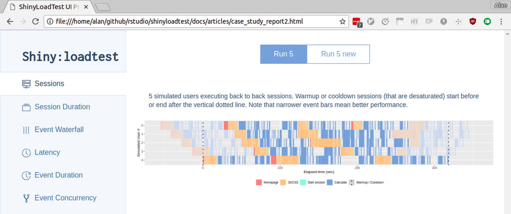

# Other approaches

## A general note

This session outlines all of the main components that are needed in a production ready application, but it is by no means the only approach

- Many approaches are used across the Shiny ecosystem
- No one approach is best
- Key considerations
  - Consistency - use the same approach across your applications
  - Clarity - make sure your structure is clear and easy to follow
  - Documentation - document your structure, so other developers can understand without having to dig through the details

## Applications as packages

- Take advantage of R package infrastructure
  - Documentation
  - Testing
- Application structure and workflow is quite different
  - Manage dependencies with DESCRIPTION
  - Launch app with a function

This is a bit more complicated, and out of the scope of this training - check out [Mastering Shiny Chapter 20: Packages](https://mastering-shiny.org/scaling-packaging.html) for a detailed overview

## Golem

📦 [golem](https://thinkr-open.github.io/golem/)

- An “opinionated framework for building production-grade shiny applications”
- Uses R package structure for applications
- Very specific way of structuring files
- Additional helper functions for the development cycle

Check out [Engineering Shiny](https://engineering-shiny.org/) for a detailed overview of building Shiny applications with golem

## Auditing applications

📦 [shinyValidator](https://opensource.nibr.com/shinyValidator/)

- Suite of tools for auditing apps built with the golem framework
- Many features
  - Testing and test coverage
  - Profiling and performance testing
  - Code analysis

Even if you’re not using golem, shinyValidator provides a very helpful overview of what you need to check when building Shiny apps. Have a look at the [Get started vignette](https://opensource.nibr.com/shinyValidator/articles/shinyValidator.html) for details of what it does and how

# Wrapping up

## Homework - Readings

### Mastering Shiny

**[Chapter 17: General guidelines](https://mastering-shiny.org/best-practices.html)**

**[Chapter 20: Packages](https://mastering-shiny.org/scaling-packaging.html)**

**[Chapter 21: Testing](https://mastering-shiny.org/scaling-testing.html)**

### Shiny articles

**[Testing](https://shiny.rstudio.com/articles/#testing)**

## Homework - Exercise

Continue with your shiny application from session 5

- Convert your application to a formal structure!
  - Create scripts under R as appropriate
- Add metadata
  - Documentation
  - Use renv
- Add tests
  - Test your modules
  - Test key components of your server function
  - Add snapshot tests
- Deploy!
  - Deploy to RStudio connect or shinyapps.io

## Goodbye!

Thanks for listening

**Introduction to Shiny** Session 6: *Application structure and workflow*